# 전처리1 - 형태조절과 문제변수 처리

## 1. Feature Enginnering

- 전처리 : 데이터를 분석하기 적합한 형태로 만듬.
- 전처리 과정 소요시간은 전체 분석과정의 약 60% 를 차지하므로 Feature Engineering 을 먼저 다루도록 하자.

### 1.1 Scaling

- 비교되는 변수의 버위가 다른 경우, 정규화로 비슷하게 맞출 수 있다.
- 정규화된 관측치 = (관측치-평균)/표준편차

```r
sc <- scale(iris[1:4]); head(sc);
```

```
##      Sepal.Length Sepal.Width Petal.Length Petal.Width
## [1,]   -0.8976739  1.01560199    -1.335752   -1.311052
## [2,]   -1.1392005 -0.13153881    -1.335752   -1.311052
## [3,]   -1.3807271  0.32731751    -1.392399   -1.311052
## [4,]   -1.5014904  0.09788935    -1.279104   -1.311052
## [5,]   -1.0184372  1.24503015    -1.335752   -1.311052
## [6,]   -0.5353840  1.93331463    -1.165809   -1.048667
```

```r
df <- as.data.frame(sc)
cb <- cbind(df, iris$Species); head(cb)
```

```
##   Sepal.Length Sepal.Width Petal.Length Petal.Width iris$Species
## 1   -0.8976739  1.01560199    -1.335752   -1.311052       setosa
## 2   -1.1392005 -0.13153881    -1.335752   -1.311052       setosa
## 3   -1.3807271  0.32731751    -1.392399   -1.311052       setosa
## 4   -1.5014904  0.09788935    -1.279104   -1.311052       setosa
## 5   -1.0184372  1.24503015    -1.335752   -1.311052       setosa
## 6   -0.5353840  1.93331463    -1.165809   -1.048667       setosa
```

### 1.2 Binning

- 관측치가 연속형이면서 범위가 너무 다양할 경우, 적절히 그룹을 지어주어 이해하기 쉽게 만들자.
- 연속형변수 -> 범주형 변수

```r
data <- read.csv("agemoney.csv",header=T)
age10 <- mean(data[data$age>=10&data$age<20,2])
age20 <- mean(data[data$age>=20&data$age<30,2])
age30 <- mean(data[data$age>=30&data$age<40,2])
age40 <- mean(data[data$age>=40&data$age<50,2])
age50 <- mean(data[data$age>=50&data$age<60,2])

data.mean <- data.frame(age=c(10, 20, 30, 40, 50), money=c(age10, age20, age30, age40, age50))
```

### 1.3 Creating Feature

- 주어진 변수만으로는 의미있는 결과가 나오지 않을 때, 변수의 속성을 추가해본다.

```r
# 텍스트 형태이 데이터를 Date 유형으로 변호
date.txt <- c("2016-11-01","2016-11-01","2016-11-03","2016-11-05")
date.txt
```

```
## [1] "2016-11-01" "2016-11-01" "2016-11-03" "2016-11-05"
```

```r
class(date.txt)
```

```
## [1] "character"
```

```r
date.as.date <- as.Date(date.txt)
date.as.date
```

```
## [1] "2016-11-01" "2016-11-01" "2016-11-03" "2016-11-05"
```

```r
class(date.as.date)
```

```
## [1] "Date"
```

```r
# 날짜의 포맷을 지정. 날짜->요일
date.as.date.week.full <- format(date.as.date, format="%Y-%m-%A")
date.as.date.week.only <- format(date.as.date, format="%A")
```

### 1.4 Creating Dummy

- 데이터의 값을 0과 1로만 나타내는 경우.
- 원 핫 인코딩(one-hot-encoding) 이라고도 한다.

```r
lvl <- factor(c('A','B','A','A','C'))
df <- data.frame(lvl); df
```

```
##   lvl
## 1   A
## 2   B
## 3   A
## 4   A
## 5   C
```

```r
dv <- model.matrix(~lvl, data=df)[,-1]; dv
```

```
##   lvlB lvlC
## 1    0    0
## 2    1    0
## 3    0    0
## 4    0    0
## 5    0    1
```

### example

#### 연습1

```r
date.txt <- c("2016-11-01","2016-11-01","2018-11-03","2019-11-05")
#1. 화, 수, 토 만 출력되게 하시오
date.as.date <- as.Date(date.txt)
date.week <- format(date.as.date, format="%a") #%A 이면 월요일, 화요일, 수요일, ... ...
date.week[date.week=="화"|date.week=="수"|date.week=="토"]
```

```
## [1] "화" "화" "토" "화"
```

```r
#2. 년도와 월이 '16-11', '17-11', '18-11', '19-11' 로 출력되게 하시오.
date.as.y.m <- format(date.week, format="%Y-%m")
date.as.y.m
```

```
## [1] "화" "화" "토" "화"
```

#### 연습2

```r
#1. Binning 을 통해 타이타닉 탑승자의 10세 단위 별 평균 생존률을 구하시오.
titanic <- read.csv("train.csv", header=T)
max(titanic$Age, na.rm = T); min(titanic$Age, na.rm = T)
```

```
## [1] 80
```

```
## [1] 0.42
```

```r
age00 <- mean(titanic[titanic$Age<10,"Survived"], na.rm=T)
age10 <- mean(titanic[titanic$Age>=10&titanic$Age<20,"Survived"], na.rm=T)
age20 <- mean(titanic[titanic$Age>=20&titanic$Age<30,"Survived"], na.rm=T)
age30 <- mean(titanic[titanic$Age>=30&titanic$Age<40,"Survived"], na.rm=T)
age40 <- mean(titanic[titanic$Age>=40&titanic$Age<50,"Survived"], na.rm=T)
age50 <- mean(titanic[titanic$Age>=50&titanic$Age<60,"Survived"], na.rm=T)
age60 <- mean(titanic[titanic$Age>=60&titanic$Age<70,"Survived"], na.rm=T)
age70 <- mean(titanic[titanic$Age>=70&titanic$Age<80,"Survived"], na.rm=T)
age80 <- mean(titanic[titanic$Age>=80&titanic$Age<90,"Survived"], na.rm=T)
age80 # 80대의 평균생존률
```

```
## [1] 1
```

```r
#2. Binning을 통해 타이타닉 탑승자의 10세 단위 별 평균 좌석등급을 구하시오.
mean.pclass <-c()
for(i in seq(0,80,10)){
  mean.pclass<-c(mean.pclass, mean(titanic[titanic$Age>=i&titanic$Age<(i+10),"Pclass"], na.rm=T)
)
}
age.names <- c('a00','a10','a20','a30','a40','a50','a60','a70','a80')
age.pclass <- data.frame(age.names, mean.pclass)
```

#### 연습3

```r
#1. 타이타닉 탑승자의 성별을 원 핫 인코딩으로 나태내시오.
onehot <- model.matrix(~Sex, data=titanic)[,-1]
head(as.data.frame(onehot)) # 남자는 1, 여자는 0 이 됨.
```

```
##   onehot
## 1      1
## 2      0
## 3      0
## 4      0
## 5      1
## 6      1
```

```r
#2. 타이타닉 탑승자의 Embarke를 원 핫 인코딩으로 나타내시오.
onehot <- model.matrix(~Embarked, data=titanic)[,-1]
head(onehot)
```

```
##   EmbarkedC EmbarkedQ EmbarkedS
## 1         0         0         1
## 2         1         0         0
## 3         0         0         1
## 4         0         0         1
## 5         0         0         1
## 6         0         1         0
```

```r
#3. 10개의 Factor를 갖는 변수를 원 핫 인코딩으로 나타내는 경우, 몇 개의 변수로 분리되는가? 9개.
```

#### 연습 4

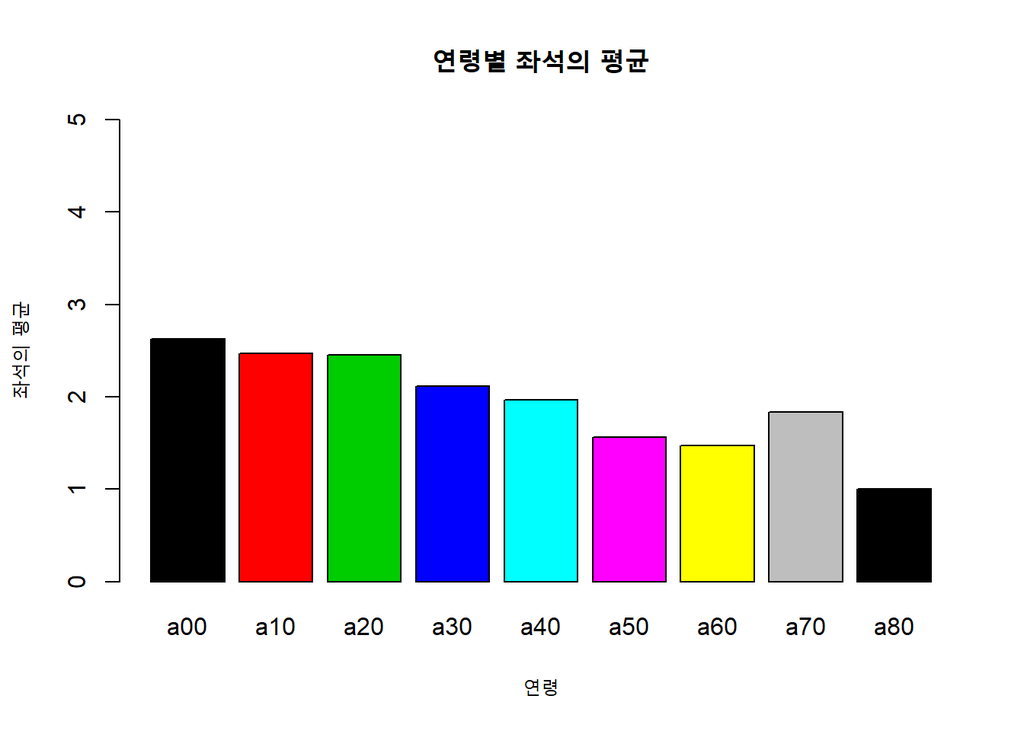

```r
#1. 연령별 좌석의 평균을 조사한 자료 문제에서 (1.4에 관련.) 이 자료를 표현하기에 가장 적절한 그래프는?
library(ggplot2)
barplot(age.pclass$mean.pclass, main="연령별 좌석의 평균",ylim=c(0,5), xlab="연령", ylab="좌석의 평균",names=age.names, col=1:length(age.names))
```

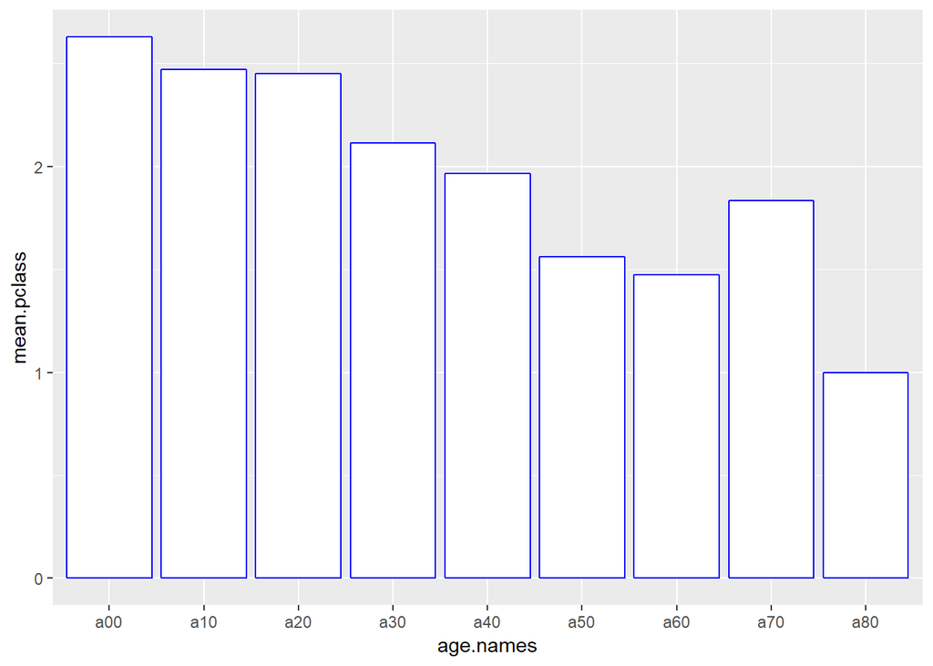

```r
ggplot(data=age.pclass, aes(x=age.names, y=mean.pclass)) + geom_bar(stat="identity", color="blue", fill="white")
```

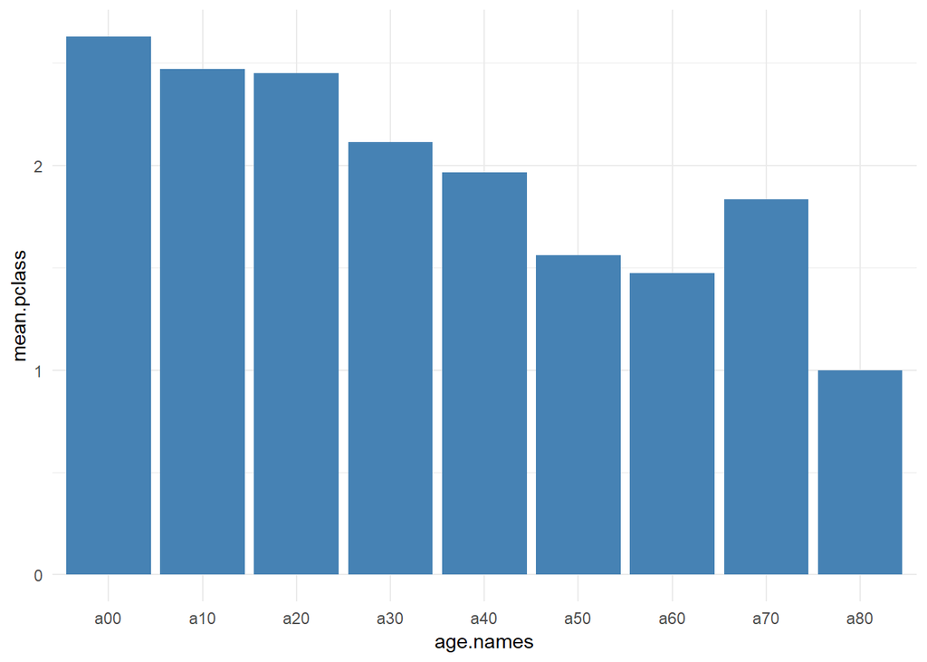

```r
ggplot(data=age.pclass, aes(x=age.names, y=mean.pclass)) +
  geom_bar(stat="identity", fill="steelblue")+
  theme_minimal()
```

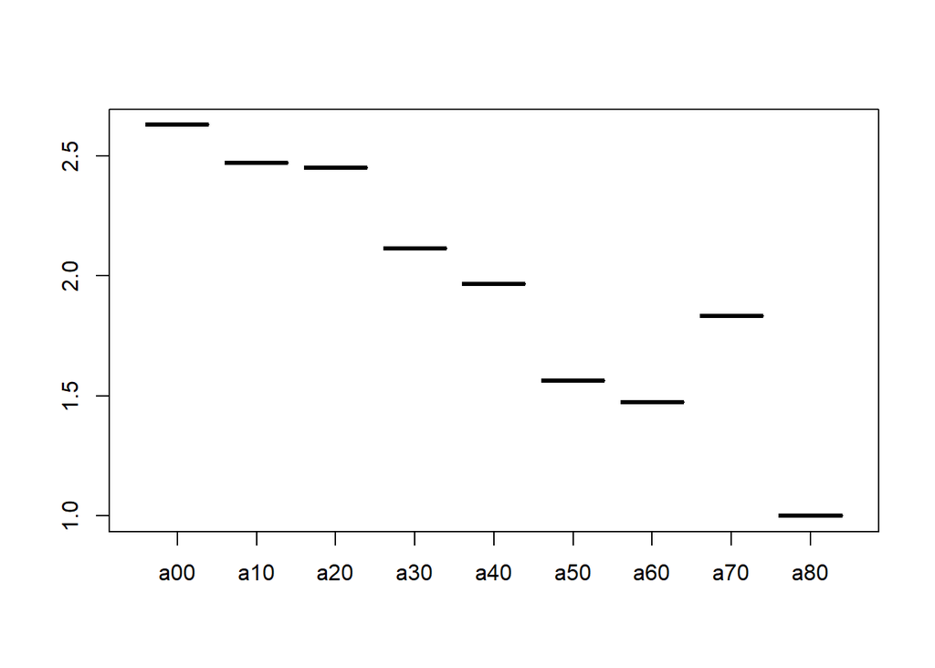

```r
plot(age.pclass$age.names, age.pclass$mean.pclass)
```

```r
#2. 도수분포표와의 차이점을 생각해보시오.
```

## 2. 데이터 프레임 처리

- R에서 가장 많이 사용되는 구조이다.
- 데이터 셋을 조작하고 저장하는 표준 자료구조.

### 2.1 데이터 프레임 생성

#### 2.1.1 파일로부터 데이터 프레임 불러오기

```r
head(read.csv("test.csv", header = T))
```

```
##   PassengerId Pclass                                         Name    Sex
## 1         892      3                             Kelly, Mr. James   male
## 2         893      3             Wilkes, Mrs. James (Ellen Needs) female
## 3         894      2                    Myles, Mr. Thomas Francis   male
## 4         895      3                             Wirz, Mr. Albert   male
## 5         896      3 Hirvonen, Mrs. Alexander (Helga E Lindqvist) female
## 6         897      3                   Svensson, Mr. Johan Cervin   male
##    Age SibSp Parch  Ticket    Fare Cabin Embarked
## 1 34.5     0     0  330911  7.8292              Q
## 2 47.0     1     0  363272  7.0000              S
## 3 62.0     0     0  240276  9.6875              Q
## 4 27.0     0     0  315154  8.6625              S
## 5 22.0     1     1 3101298 12.2875              S
## 6 14.0     0     0    7538  9.2250              S
```

#### 2.1.2 data.frame() 으로 만들기

```r
x<- c(1,2,3,4,5)
y<-c(10,20,30,40,50)
z<-c('M','M','M','F','F')
d<-data.frame(x,y,z); d
```

```
##   x  y z
## 1 1 10 M
## 2 2 20 M
## 3 3 30 M
## 4 4 40 F
## 5 5 50 F
```

#### 2.1.3 데이터 프레임 주의사항: stringsAsFactors

```r
id <-c(1,2,3,4,5)
factory <- c('평택지부1','평택지부2','안산지부','인천지부','원주지부')
sales <- c(80,90,80,85,87)
d<-data.frame(id,factory,sales);
str(d) # 문자열이 Factor 타입으로 저장되었다는 것을 알 수 있음.
```

```
## 'data.frame':    5 obs. of  3 variables:
##  $ id     : num  1 2 3 4 5
##  $ factory: Factor w/ 5 levels "안산지부","원주지부",..: 4 5 1 3 2
##  $ sales  : num  80 90 80 85 87
```

#### 2.1.4 특정 컬럼 데이터 유형 변환

```r
id<-c(1,2,3,4,5)
factor<-c('평택1','평택2','안산','인청','원주')
type<-c('공장','공장','오피스','오피스','오피스')
sales <-c(70,90,80,85,87)
df <- data.frame(id,factory, type,sales, stringsAsFactors=FALSE)
str(df)
```

```
## 'data.frame':    5 obs. of  4 variables:
##  $ id     : num  1 2 3 4 5
##  $ factory: chr  "평택지부1" "평택지부2" "안산지부" "인천지부" ...
##  $ type   : chr  "공장" "공장" "오피스" "오피스" ...
##  $ sales  : num  70 90 80 85 87
```

```r
# factor 선언을 원하는 변수만 설정해주기
df$type <- as.factor(df$type)
str(df)
```

```
## 'data.frame':    5 obs. of  4 variables:
##  $ id     : num  1 2 3 4 5
##  $ factory: chr  "평택지부1" "평택지부2" "안산지부" "인천지부" ...
##  $ type   : Factor w/ 2 levels "공장","오피스": 1 1 2 2 2
##  $ sales  : num  70 90 80 85 87
```

### 2.2 데이터 다루기

#### 2.2.1 특정 컬럼 선택

```r
id <- 1:3
name <- c('아자르','산체스','메시')
gender<-c('m','m','m')
rank<-c(2,3,1)
df <- data.frame(id,name,gender,rank, stringsAsFactors = FALSE)

# 아래 셋다 모두 같은 결과라는 사실 !
df.col <- df[,2]
df.col <- df[,'name']
df.col <- df$name
```

-만약 결과를 벡터가 아닌 데이터프레임으로 나오게 하려면 dplyr패키지의 select() 함수를 사용한다.특정 컬럼 추출을 해도 데이터 프레임 형태를 유지한다. `

```r
library(dplyr)
df %>% select(name) # 데이터 프레임 형식으로 데이터 프레임 속 특정 컬럼을 불러올 수 있다.
```

```
##     name
## 1 아자르
## 2 산체스
## 3   메시
```

#### 2.2.2 여러 컬럼 선택

```r
df.cols <- df[,c(2,3,4)] # 2,3,4 컬럼 선택
df.cols <- df[,2:4]
df.cols <- df[,c("name","gender","rank")]
```

#### 2.2.3 행 및 원소 선택

```r
df.row <- df[2,] # 특정 행 선택
df.row
```

```
##   id   name gender rank
## 2  2 산체스      m    3
```

```r
df.element <- df[2,3] # 특정 원소 선택
df.element
```

```
## [1] "m"
```

#### 2.2.4 조건에 맞는 행 선택 1

```r
df.man <- df[df$gender=='m',] # gender 가 m 인 행이 TRUE인 행만 가져온다.
df.man
```

```
##   id   name gender rank
## 1  1 아자르      m    2
## 2  2 산체스      m    3
## 3  3   메시      m    1
```

#### 2.2.5 조건식 활용

```r
df[(df$rank>=2)&(df$name=='아자르'),]
```

```
##   id   name gender rank
## 1  1 아자르      m    2
```

#### 2.2.6 조건에 맞는 행 선택 2

[which(), ]

```r
df.man <- df[which(df$gender=='m'),]
which(df$gender=='m') # 조건에 맞는 인덱스를 출력
```

```
## [1] 1 2 3
```

#### 2.2.7 which 조건식 활용

[which() & which() , ][which() | which() , ]

```r
df[which(df$gender=='m')&(df$rank>2),]
```

```
##   id   name gender rank
## 2  2 산체스      m    3
```

```r
df[which(df$gender=='m')|(df$rank>2),]
```

```
##   id   name gender rank
## 1  1 아자르      m    2
## 2  2 산체스      m    3
## 3  3   메시      m    1
```

#### 2.2.8 조건에 맞는 행 선택 3

- Factor 에 대해서도 사용이 가능하다.
- 쉼표 구분을 하지 않아도 된다.
- selece=c() 를 통하여 원하는 컬럼을 가져올 수 있다.

```r
df.man <- subset(df,gender=='m')
df.man
```

```
##   id   name gender rank
## 1  1 아자르      m    2
## 2  2 산체스      m    3
## 3  3   메시      m    1
```

```r
df.man <- subset(df,df$gender=='m') # df$gender를 사용해도 가능하다.

subset(df, gender=='m', select = c('name','rank'))
```

```
##     name rank
## 1 아자르    2
## 2 산체스    3
## 3   메시    1
```

#### 2.2.9 subset 조건식 활용

```r
subset(df, rank>=2)
```

```
##   id   name gender rank
## 1  1 아자르      m    2
## 2  2 산체스      m    3
```

```r
subset(df, rank>=2 & name=='산체스')
```

```
##   id   name gender rank
## 2  2 산체스      m    3
```

```r
subset(df, rank>=2 | name=='메시')
```

```
##   id   name gender rank
## 1  1 아자르      m    2
## 2  2 산체스      m    3
## 3  3   메시      m    1
```

```r
subset(df, rank>=2 | name=='메시', select=c('rank','name'))
```

```
##   rank   name
## 1    2 아자르
## 2    3 산체스
## 3    1   메시
```

#### 2.2.10 조건에 맞는 행 선택 4. **filter(data, logical) 함수.**

```r
df.man <- df%>%filter(gender == 'm') # gender 가 'm' 인 행을 추출!
df.man
```

```
##   id   name gender rank
## 1  1 아자르      m    2
## 2  2 산체스      m    3
## 3  3   메시      m    1
```

#### 2.2.11 filter()의 조건식 활용

```r
df %>% filter(name=='m')
```

```
## [1] id     name   gender rank
## <0 rows> (or 0-length row.names)
```

```r
df %>% filter( rank>=2 | name=='m')
```

```
##   id   name gender rank
## 1  1 아자르      m    2
## 2  2 산체스      m    3
```

#### 2.2.12 특정 요소 제외

```r
df[,-2] # 2열 제외
```

```
##   id gender rank
## 1  1      m    2
## 2  2      m    3
## 3  3      m    1
```

```r
df[-2,] # 2행 제외
```

```
##   id   name gender rank
## 1  1 아자르      m    2
## 3  3   메시      m    1
```

```r
df[,-c(1,3)] # 1,3 열 제외
```

```
##     name rank
## 1 아자르    2
## 2 산체스    3
## 3   메시    1
```

#### 2.2.13 살펴보기. head(data, n), tail(data, n), View(data) 함수.

```r
# head(), tail(), View()
```

### 2.3 데이터 추후 연결하기

#### 2.3.1 새 데이터 프레임 생성. cbind()

```r
x1<-c(1,2,3)
x2<-c(4,5,6)
x3<-c(7,8,9)
df <- data.frame(x1,x2,x3)
x4<-c(10,11,12)
df2 <- cbind(df,x4)
x5<-c('James','Mary','Tony')
df3 <- cbind(df2, x5, stringsAsFactors=FALSE)
df3
```

```
##   x1 x2 x3 x4    x5
## 1  1  4  7 10 James
## 2  2  5  8 11  Mary
## 3  3  6  9 12  Tony
```

`df3$This_is_new_value <- x5 도 cbind 처럼 새로운 열을 추가할 수 있다. stringsAsFactors=FALSE옵션을 사용하지 않아도 된다`

#### 2.3.2 파생변수 만들기

```r
x1<-c(1,2,3)
x2<-c(4,5,6)
x3<-c(7,8,9)
df <- data.frame(x1,x2,x3)

df$sum <- df$x1+df$x2+df$x3 # 세 변수의 합을 가지는 변수 생성
df
```

```
##   x1 x2 x3 sum
## 1  1  4  7  12
## 2  2  5  8  15
## 3  3  6  9  18
```

```r
df$pass <- ifelse(df$sum>15,'pass','fail')
df
```

```
##   x1 x2 x3 sum pass
## 1  1  4  7  12 fail
## 2  2  5  8  15 fail
## 3  3  6  9  18 pass
```

#### 2.3.3 두 개의 데이터프레임을 같은 기준으로 묶을 때

```r
a <- data.frame(id=c(1,2,3,4,5), mid=c(30,40,50,60,70))
b <- data.frame(id=c(5,4,3,2,1), final=c(70,90,100,90,80))
#library(dplyr)
left_join(a,b,by="id")
```

```
##   id mid final
## 1  1  30    80
## 2  2  40    90
## 3  3  50   100
## 4  4  60    90
## 5  5  70    70
```

#### 2.3.4 컬럼 이름 바꾸기. rename(datam , new_colname, old_colname)

```r
name <- c('a','b')
age <- c(23,25)
df <- data.frame(name,age)
rename(df,job=name)
```

```
##   job age
## 1   a  23
## 2   b  25
```

```r
df
```

```
##   name age
## 1    a  23
## 2    b  25
```

### example

#### 연습1

```r
#1. 타이타닉 데이터 셋을 남여로 나누어 구분하고, 각각에 대한 생존율을 구하시오.
titanic_man <- titanic[titanic$Sex=='male',]
titanic_woman <- titanic[titanic$Sex=='female',]
man_s <- mean(titanic_man$Survived)
woman_s <- mean(titanic_woman$Survived)
man_s;woman_s;
```

```
## [1] 0.1889081
```

```
## [1] 0.7420382
```

#### 연습2

```r
#2. 남성이면서, 10대 미만, 10대, 20대의 생존율을 구하시오.
man_under00 <- mean(titanic_man[titanic_man$Age<10,'Survived'], na.rm = T)
man_under10 <- mean(titanic_man[titanic_man$Age>=10&titanic_man$Age<20,'Survived'], na.rm = T)
man_under20 <- mean(titanic_man[titanic_man$Age>=20&titanic_man$Age<30,'Survived'], na.rm = T)
cat("생존율.  10대:", man_under00," 20대: " ,man_under10, " 30대", man_under20)
```

```
## 생존율.  10대: 0.59375  20대:  0.122807  30대 0.1689189
```

```r
#3. 여성이면서, 10대 미만, 10대, 20대의 생존율을 구하시오.
woman_under00 <- mean(titanic_woman[titanic_woman$Age<10,'Survived'], na.rm = T)
woman_under10 <- mean(titanic_woman[titanic_woman$Age>=10&titanic_woman$Age<20,'Survived'], na.rm = T)
woman_under20 <- mean(titanic_woman[titanic_woman$Age>=20&titanic_woman$Age<30,'Survived'], na.rm = T)
cat("생존율.  10대:", woman_under00," 20대: " ,woman_under10, " 30대", woman_under20)
```

```
## 생존율.  10대: 0.6333333  20대:  0.7555556  30대 0.7222222
```

## 3. 데이터 분리

### 3.1 데이터 분리 관련 함수

- 데이터를 특정 구간별로 나눠본다.
- sample(), split(), ifelse()

### 3.2 sample()함수

```r
sample(1:10,5) #1에서 10 중 5개를 뽑는다.
```

```
## [1] 7 5 1 3 8
```

```r
sample(1:10,10) # 1에서 10을 단순히 섞는 용도로도 사용한다.
```

```
##  [1]  7  1  4 10  2  3  8  9  6  5
```

#### 3.3 split() 함수

```r
iris.s <- split(iris, iris$Species) # 데이터를 Species에 따라 분리한다.
iris.s <- split(iris, 1:10) # 하나부터 열개까지로 나눈다.
head(iris.s$`1`)
```

```
##    Sepal.Length Sepal.Width Petal.Length Petal.Width    Species
## 1           5.1         3.5          1.4         0.2     setosa
## 11          5.4         3.7          1.5         0.2     setosa
## 21          5.4         3.4          1.7         0.2     setosa
## 31          4.8         3.1          1.6         0.2     setosa
## 41          5.0         3.5          1.3         0.3     setosa
## 51          7.0         3.2          4.7         1.4 versicolor
```

`나누어진 그룹은 리스트로써 출력이 된다.`

#### 3.4 ifelse() 연습1

```r
autoparts <- read.csv("autoparts.csv",header=TRUE)
autoparts1 <- autoparts[autoparts$prod_no=="90784-76001",c(2:11)]
autoparts2 <- autoparts1[autoparts1$c_thickness < 1000,]
head(autoparts2)
```

```
##   fix_time a_speed b_speed separation s_separation rate_terms  mpa
## 1     85.5   0.611   1.715      242.0        657.6         95 78.2
## 2     86.2   0.606   1.708      244.7        657.1         95 77.9
## 3     86.0   0.609   1.715      242.7        657.5         95 78.0
## 4     86.1   0.610   1.718      241.9        657.3         95 78.2
## 5     86.1   0.603   1.704      242.5        657.3         95 77.9
## 6     86.3   0.606   1.707      244.5        656.9         95 77.9
##   load_time highpressure_time c_thickness
## 1      18.1                58        24.7
## 2      18.2                58        22.5
## 3      18.1                82        24.1
## 4      18.1                74        25.1
## 5      18.2                56        24.5
## 6      18.0                78        22.9
```

```r
autoparts2$y_faulty <- ifelse(autoparts2$c_thickness<20|autoparts2$c_thickness>32,1,0)
```

#### 3.5 ifelse() 연습2. ifelse를 중복해서 사용한다.

```r
autoparts2$g_class <- factor(ifelse(autoparts2$c_thickness>32,3, ifelse(autoparts2$c_thickness<20,2,1)))
```

#### 3.6 자료 준비의 예

```r
autoparts <- read.csv("autoparts.csv",header=TRUE)
autoparts1 <- autoparts[autoparts$prod_no=="90784-76001",c(2:11)]
autoparts2 <- autoparts1[autoparts1$c_thickness < 1000,]
t_index <- sample(1:nrow(autoparts2), size=nrow(autoparts2)*0.7)
train <- autoparts2[t_index,]
test <- autoparts2[-t_index,]
nrow(train); nrow(test);
```

```
## [1] 15236
```

```
## [1] 6531
```

### example

#### 연습1

```r
# 타이타닉 데이터에서 parch는 부모, 자식 수를 의미함.
#1. 15세 미만이면서 parch 가 0 보다 큰 경우 부모와 함께 탑승한 경우로 볼 수 있다. 15세 미만이면서 parch가 0보다 큰 경우에 해당하는 탑승객은 몇 명인가?
titanic <- read.csv("train.csv",header=T)
NROW(titanic[(titanic$Age < 15)&(titanic$Parch>0),])
```

```
## [1] 90
```

```r
titanic$parch2 <- ifelse((titanic$Age < 15)&(titanic$Parch>0),1,0)
titanic.s<-split(titanic, titanic$parch2)
mean(titanic.s$`0`$Survived)
```

```
## [1] 0.3707865
```

```r
mean(titanic.s$`1`$Survived)
```

```
## [1] 0.5714286
```

```r
#2. Split 함수를 이용하여, 15세 미만이면서 parch가 0인 그룹의 생존률과 parch가 1이상인 그룹의 생존률을 구하시오.
titanic$parch3 <- ifelse((titanic$Age < 15)&(titanic$Parch==0),1,0)
titanic$parch4 <- ifelse((titanic$Parch>=1),1,0)
titanic.s.3 <- split(titanic, titanic$parch3)
titanic.s.4 <- split(titanic, titanic$parch4)
mean(titanic.s.3$`1`$Survived) # parch가 0이고 15세 미만인 그룹의 생존률
```

```
## [1] 0.625
```

```r
mean(titanic.s.4$`1`$Survived) # parch가 1이상인 그룹의 생존률
```

```
## [1] 0.5117371
```

## 4. 결측치 처리

### 4.1 결측치

- 적절한 처리는 필수적이다 ~!

### 4.2 제거와 치환

- 제거: 전체데이터크기에 비해 결측치가 작으면 제거한다. 자료 값을 임의로 바꾸지 않는다는 데에 의미가 있다.
- 치환: 결측치가 많거나, 원소의 개수가 보존되어야 하는 경우에 치환. 자료의 개수를 보존한다.

### 4.3 결측치 확인. is.na() 함수: TRUE 혹은 FALSE 를 반환함.

#### 4.3.1 결측치 확인

```r
x <- c(1,NA,3,2,2)
is.na(x)
```

```
## [1] FALSE  TRUE FALSE FALSE FALSE
```

#### 4.3.2 연습-데이터 확인

```r
# 데이터 불러오기
autoparts <- read.csv("autoparts.csv")
dim(autoparts)
```

```
## [1] 34139    11
```

```r
head(is.na(autoparts))
```

```
##      prod_no fix_time a_speed b_speed separation s_separation rate_terms
## [1,]   FALSE    FALSE   FALSE   FALSE      FALSE        FALSE      FALSE
## [2,]   FALSE    FALSE   FALSE   FALSE      FALSE        FALSE      FALSE
## [3,]   FALSE    FALSE   FALSE   FALSE      FALSE        FALSE      FALSE
## [4,]   FALSE    FALSE   FALSE   FALSE      FALSE        FALSE      FALSE
## [5,]   FALSE    FALSE   FALSE   FALSE      FALSE        FALSE      FALSE
## [6,]   FALSE    FALSE   FALSE   FALSE      FALSE        FALSE      FALSE
##        mpa load_time highpressure_time c_thickness
## [1,] FALSE     FALSE             FALSE       FALSE
## [2,] FALSE     FALSE             FALSE       FALSE
## [3,] FALSE     FALSE             FALSE       FALSE
## [4,] FALSE     FALSE             FALSE       FALSE
## [5,] FALSE     FALSE             FALSE       FALSE
## [6,] FALSE     FALSE             FALSE       FALSE
```

`sum()을 활용하여 눈으로 확인하기 힘든 부분을 보완해보자 !`

```r
sum(is.na(autoparts))
```

```
## [1] 0
```

**autoparts 데이터는 총 NA의 개수가 0이므로 결측치가 없다.**

#### 4.3.3 complete.cses()

- NA가 아니면 TRUE 를 반환한다.
- 행렬과 데이터프레임에서는 NA 가 하나도 없어야 그행을 TRUE로 반환한다.
- ** 데이터프레임이나 행렬에 좋다.**

```r
library(reshape2)
head(french_fries)
```

```
##    time treatment subject rep potato buttery grassy rancid painty
## 61    1         1       3   1    2.9     0.0    0.0    0.0    5.5
## 25    1         1       3   2   14.0     0.0    0.0    1.1    0.0
## 62    1         1      10   1   11.0     6.4    0.0    0.0    0.0
## 26    1         1      10   2    9.9     5.9    2.9    2.2    0.0
## 63    1         1      15   1    1.2     0.1    0.0    1.1    5.1
## 27    1         1      15   2    8.8     3.0    3.6    1.5    2.3
```

```r
french_fries[!complete.cases(french_fries),]
```

```
##     time treatment subject rep potato buttery grassy rancid painty
## 315    5         3      15   1     NA      NA     NA     NA     NA
## 455    7         2      79   1    7.3      NA    0.0    0.7      0
## 515    8         1      79   1   10.5      NA    0.0    0.5      0
## 520    8         2      16   1    4.5      NA    1.4    6.7      0
## 563    8         2      79   2    5.7       0    1.4    2.3     NA
```

#### 4.3.4 **결측치의 인덱스만 확인하고자 할 때**

```r
which(!complete.cases(french_fries))
```

```
## [1] 341 477 525 535 550
```

```r
na.idx <- french_fries[which(!complete.cases(french_fries)),]

nrow(french_fries); nrow(na.idx);
```

```
## [1] 696
```

```
## [1] 5
```

### 4.4 결측치 처리 1 (제거)

```r
x <- 1:5
y <- c(2,4,NA,8,10)
df <- data.frame(x,y)
idx <- which(!complete.cases(df))
df[-idx,] # NA 가 없는 데이터 프레임이 완성된다 !
```

```
##   x  y
## 1 1  2
## 2 2  4
## 4 4  8
## 5 5 10
```

### 4.5 결측치 처리2 (na.rm 제거)

- 결측치가 있으면 제산이 이루어지지 않는다.
- na.rm=TRUE 옵션을 통해 NA를 제거한다.

```r
x <- c(1,2,NA,4,5)
mean(x) # 계산이 안된다.
```

```
## [1] NA
```

```r
mean(x, na.rm = TRUE) # NA를 빼고 계산한 결과가 반환된다.
```

```
## [1] 3
```

### 4.6 결측치 처리3 (함수로 제거)

- na.omit(), na.exclude() : 결측치를 제거하고 출력한다.
- na.fail(): NA있으면 실패!
- na.pass(): NA 여부에 상관없이 출력!

```r
x<-1:5; y<-c(2,4,NA,8,10); df<-data.frame(x,y)

na.omit(df); na.exclude(df);
```

```
##   x  y
## 1 1  2
## 2 2  4
## 4 4  8
## 5 5 10
```

```
##   x  y
## 1 1  2
## 2 2  4
## 4 4  8
## 5 5 10
```

```r
# na.fail(df) # NA가 있으면 실패
na.pass(df) # NA 여부에 상관없이 출력
```

```
##   x  y
## 1 1  2
## 2 2  4
## 3 3 NA
## 4 4  8
## 5 5 10
```

### 4.4 결측치 처리4. na.action

```r
x<-1:5; y<-c(2,4,NA,8,10); df<-data.frame(x,y)
resid(lm(y~x, data=df, na.action = na.omit))
```

```
##             1             2             4             5
## -7.423409e-16  9.696420e-16  6.043761e-17 -2.877387e-16
```

```r
resid(lm(y~x, dat=df, na.action = na.exclude))
```

```
##             1             2             3             4             5
## -7.423409e-16  9.696420e-16            NA  6.043761e-17 -2.877387e-16
```

### 4.5 결측치 처리5. (0으로 치환)

- 결측치를 모두 0으로 간주할 수 있는 경우에 사용한다.
- 예를 들면 성과가 있는 경우만 기록하는 경우는 0을 굳이 입력을 안하는 일이 생긴다.

`NA 을 0으로 채워준다.`

```r
x <- c(1,2,3,NA,5,NA,7)
x[is.na(x)]<-0
x
```

```
## [1] 1 2 3 0 5 0 7
```

#### 4.5.1 결측치 처리5 연습

```r
french_fries$buttery[is.na(french_fries$buttery)] <- 0
french_fries[!complete.cases(french_fries),]
```

```
##     time treatment subject rep potato buttery grassy rancid painty
## 315    5         3      15   1     NA       0     NA     NA     NA
## 563    8         2      79   2    5.7       0    1.4    2.3     NA
```

### 4.6 결측치 처리6 (치환)

- 0이 너무 낮은 값인 경우, 평균값, 중앙값, 최빈값 등을 사용한다.
- 신뢰도 문제가 발생할 수 있다는 점이 단점이다.

```r
x <- c(1,2,3,NA,5,NA,7)
x[is.na(x)] <- mean(x, na.rm = TRUE) # NA 자리에 평균값을 넣어준다.
x
```

```
## [1] 1.0 2.0 3.0 3.6 5.0 3.6 7.0
```

```r
french_fries$buttery[is.na(french_fries$buttery)] <- mean(french_fries$buttery, na.rm = TRUE)
french_fries[!complete.cases(french_fries),]
```

```
##     time treatment subject rep potato buttery grassy rancid painty
## 315    5         3      15   1     NA       0     NA     NA     NA
## 563    8         2      79   2    5.7       0    1.4    2.3     NA
```

```r
# buttery의 NA 가 0으로 치환된 것을 알 수 있다.
```

### example

#### 연습1

#### 연습2

```r
#1. 타이타닉 데이터에서 결측치가 존재하는 행은 모두 몇 개 인가?
titanic <- read.csv("train.csv",header = T)
cat("결측치가 존재하는 행 : ", nrow(titanic[!complete.cases(titanic),]))
```

```
## 결측치가 존재하는 행 :  177
```

```r
#2. 각 변수에 대해 결측치가 존재하는지를 찾아보고, 각 변수 별 결측치의 개수를 탐색하시오.
#  - Cabin 과 Embarked의 ""로 존재하는 factor를 결측치로 보는 겨우 해당 변수에는, 몇 개의 결측치가 존재하는가?

for(k in names(titanic)){
  cat("number of NA in ",k," = " ,NROW(titanic[,k][is.na(titanic[,k])]) , "\n")
}
```

```
## number of NA in  PassengerId  =  0
## number of NA in  Survived  =  0
## number of NA in  Pclass  =  0
## number of NA in  Name  =  0
## number of NA in  Sex  =  0
## number of NA in  Age  =  177
## number of NA in  SibSp  =  0
## number of NA in  Parch  =  0
## number of NA in  Ticket  =  0
## number of NA in  Fare  =  0
## number of NA in  Cabin  =  0
## number of NA in  Embarked  =  0
```

```r
# 두 변수중 "" 인 것들의 개수
sum(titanic$Cabin=="")
```

```
## [1] 687
```

```r
sum(titanic$Embarked=="")
```

```
## [1] 2
```

```r
#3. 나이(Age)에 대한 값을 나이의 median()으로 치환하시오.
titanic$Age[is.na(titanic$Age)] <- median(titanic$Age, na.rm=TRUE)
```

## 5. 이상현상 탐지

### 5.1 이상현상 탐지

#### 5.1.1 이상치 (이상점,outlier,영향점, influential points)

- 다른 데이터보다 아주 작은 값이나 큰 값.
- 의사결정에 영향을 미칠 수 있다.
- 빈도에 비해 큰영향력을 가지므로 정확한 모수 추정에 어려움을 준다.
- 항상 의미없진 않음. 그 데이터에 대한 지식을 가지고 있는 전문가가 이상치에 대해 검토하는게 바람직하다.

  ```
  - 결측치:NA, 이상치:outlier.
  ```

#### 5.1.2 이상치 처리방법

1. 제거: 오타, 오류, 비상식적 응답
2. 치환: 제거가 어려운 경우, 평균, 최빈값, 중앙값, 예측값 등으로 치환.
3. 분리: *독립변수가 충분히 세분되지 않은 경우* 이상치 발생. 이런 경우엔 변수를 세분하여 이상치 분리.

#### 5.1.3 이상치 확인

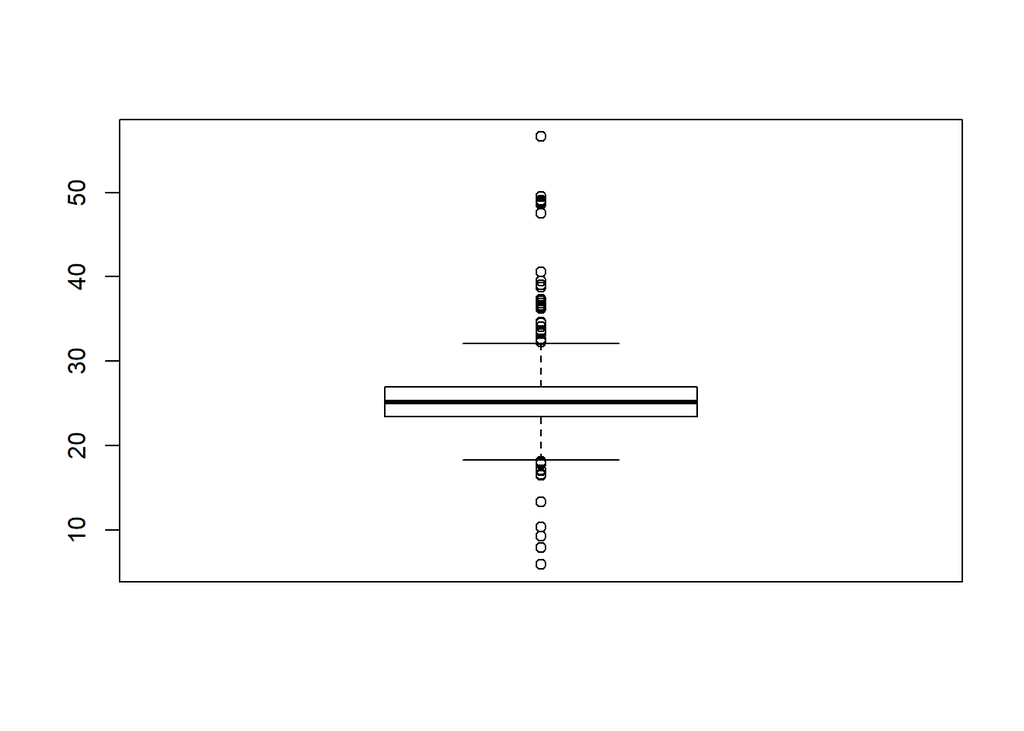

```r
autoparts <- read.csv("autoparts.csv",header = T)
autoparts3 <- autoparts[autoparts$prod_no=='45231-3B610',-1]
boxplot(autoparts3$c_thickness)
```

`이상치들은 왜 이상치일까? 그러한 데이터 들의 수가 적기 때문에.` `상자그림에서 이상치 추출하기`

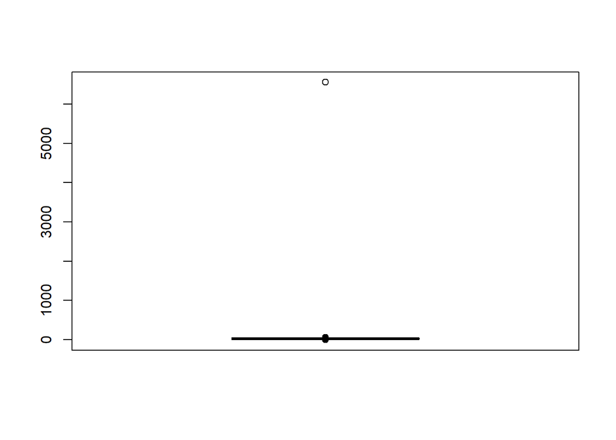

```r
myboxplot <- boxplot(autoparts$c_thickness)
```

```r
head(myboxplot$out,50)
```

```
##  [1] 34.3 36.7 35.7 33.8 16.9 34.1 36.4 36.5 32.5 37.9 35.3 34.9 33.5 17.1
## [15] 16.7 17.0 16.1 11.0 39.2 42.7 39.1 36.5 39.2 35.7 37.9 34.7 39.4 38.6
## [29] 11.4 42.4 41.1 37.8 37.4  7.2 33.7 36.7 38.2 36.0 37.2 38.8 39.1 42.3
## [43] 38.0 13.7 36.8 42.8 39.8 38.0  9.5 41.3
```

### 5.2 이상치 검출 1

#### 5.2.1 사분위수 이용하기

- 사분위수를 이용하여 이상치를 검출한다.
- 낮은 이상치 : Q1 - 1.5 * 사분위편차 보다 작은 값
- 높은 이상치 : Q3 + 1.5 * 사분위편차 보다 높은 값

```r
data <- autoparts3$c_thickness
# which(data < fivenum(data)[2] - 1.5 * IQR(data)) # fivenum(x)[2] 는 제 1사분위수
# which(data < fivenum(data)[4] + 1.5 * IQR(data)) # fivenum(x)[4] 는 제 3사분위수
fivenum(data)
```

```
## [1]  5.9 23.4 25.1 26.9 56.6
```

```r
# IQR(inter quantile range, 사분위편차) : 3사분위수 - 1사분위수
```

### example

#### 연습

`which함수를 이용하여 직접 구한 이상치와 boxplot 이 제시한 이상치 비교하기.`

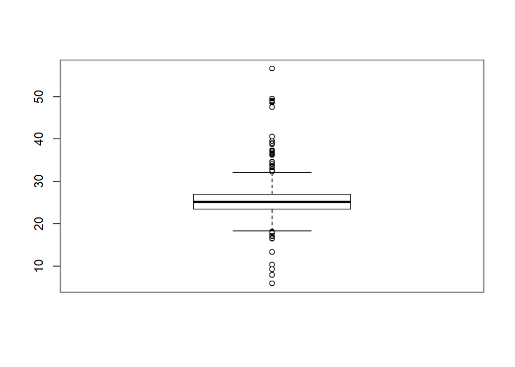

```r
a <- autoparts3$c_thickness
upper <- which(a<fivenum(a)[2] - 1.5 * IQR(a))
lower <- which(a>fivenum(a)[4] + 1.5 * IQR(a))

outlier1 <- c(a[upper],a[lower])

myboxplot <- boxplot(a)
```

```r
outlier2 <- myboxplot$out


length(outlier1)
```

```
## [1] 50
```

```r
length(outlier2)
```

```
## [1] 50
```

### 5.3 이상치 검출 2

#### 5.3.1 잔차 계산

- 회귀분석 후 예측값과 실제값의 차이인 잔차가 큰 값을 이상치로 삼는다.

```r
m <- lm(c_thickness~., data=autoparts3)
# rstudent(m)
```

`rstudent()는 외면 스튜던트화 잔차로 불리며, 잔차를 전체 잔차의 표준편차로 나눈 값이다. 이 때 , i번째 스튜던트화 잔차를 구할 때 i번째를 제외하여 표준편차를 구하므로 외면 스튜던트화잔차 라고 한다.`

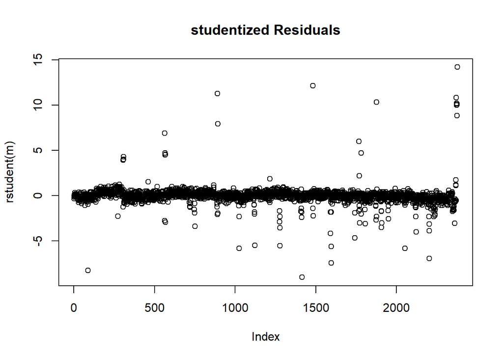

```r
plot(rstudent(m), main="studentized Residuals")
```

`car`패키지의 이상치 자동 탐색 함수.

```r
#install.packages("car")
library(car)
outlierTest(m) # 여기에 제시된 데잉터들은 통계적으로 유의미하게 잔차가 큰 값이다.(Bonferonni p < 0.05) : 독립변수가 많아질수록 값이 커지는 현상을 보정한 값이다.
```

```
##        rstudent unadjusted p-value Bonferonni p
## 21157 14.215108         4.5579e-44   1.0839e-40
## 20262 12.182360         3.7124e-33   8.8281e-30
## 19670 11.297318         7.3111e-29   1.7386e-25
## 21151 10.834554         9.8972e-27   2.3536e-23
## 20655 10.355221         1.3170e-24   3.1319e-21
## 21153 10.226805         4.7210e-24   1.1227e-20
## 21154 10.164636         8.7141e-24   2.0722e-20
## 21155 10.046863         2.7573e-23   6.5570e-20
## 21152 10.018596         3.6290e-23   8.6296e-20
## 20193 -9.002669         4.4145e-19   1.0498e-15
```

```r
x <- outlierTest(m)
x$rstudent
```

```
##     21157     20262     19670     21151     20655     21153     21154
## 14.215108 12.182360 11.297318 10.834554 10.355221 10.226805 10.164636
##     21155     21152     20193
## 10.046863 10.018596 -9.002669
```

```r
names(x$rstudent) #잔차를 찾음
```

```
##  [1] "21157" "20262" "19670" "21151" "20655" "21153" "21154" "21155"
##  [9] "21152" "20193"
```

### 5.4 이상치 검출 3

#### 5.4.1 쿡의 거리 이용

- 회귀 직선의 모양에 크게 영향을 끼치는 점을 찾는 방법.
- 레버리지(설명 변수가 극단에 치우쳐 있는 정도)와 잔차에 비례한다.
- 이상치: 쿡의 거리 > 4/데이터개수
- 쿡읭 거리는 표준화된 잔차의 합이다.

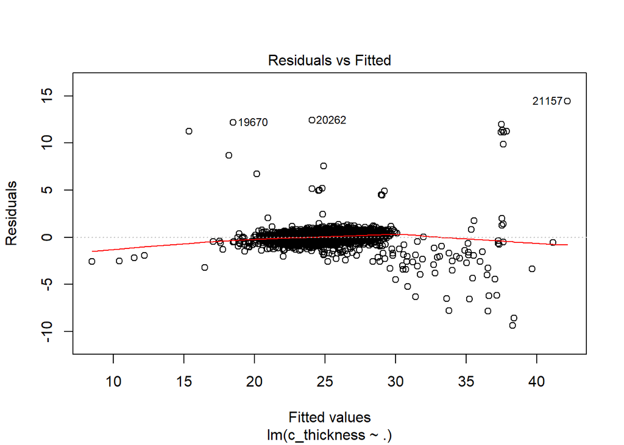

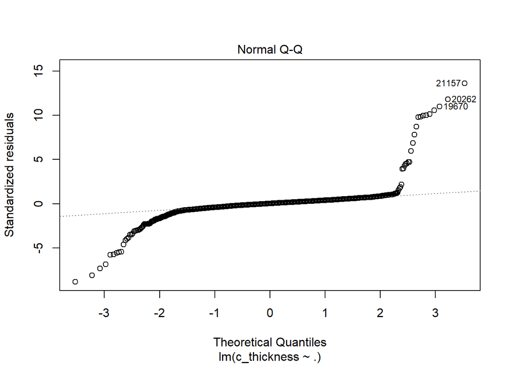

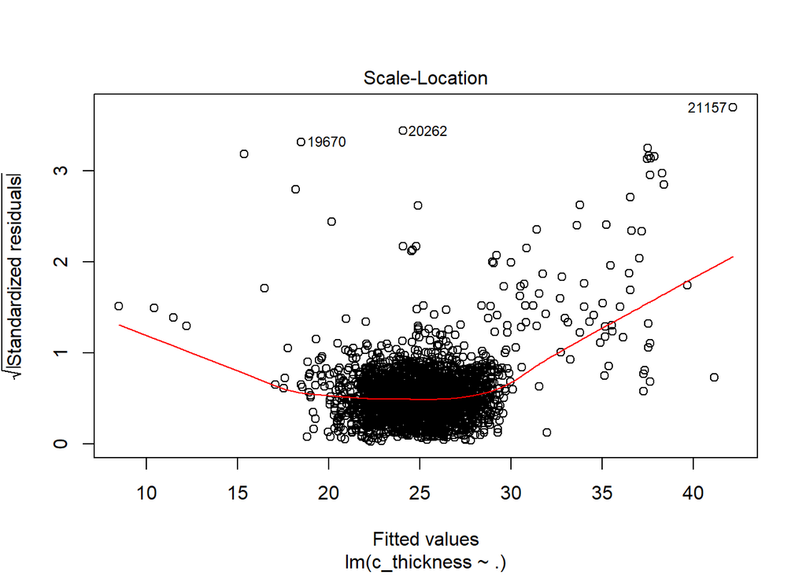

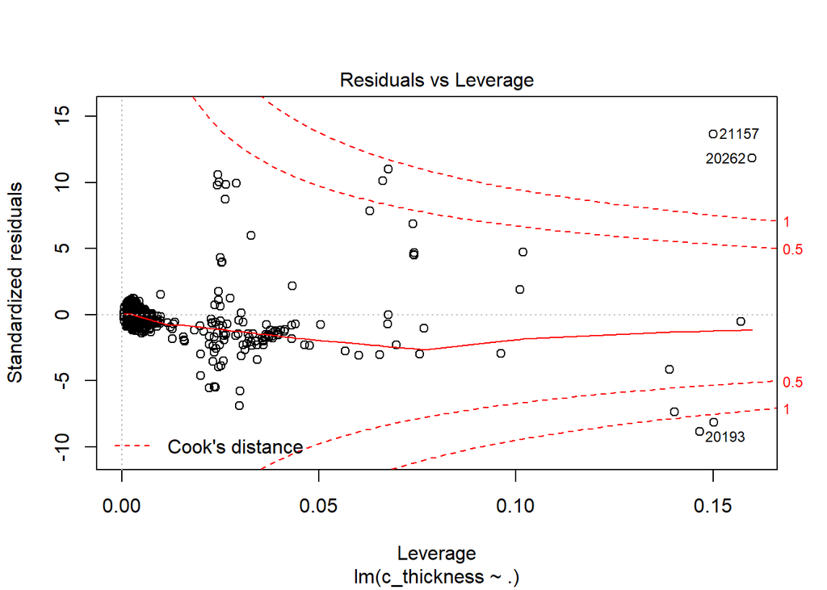

```r
plot(m)
```

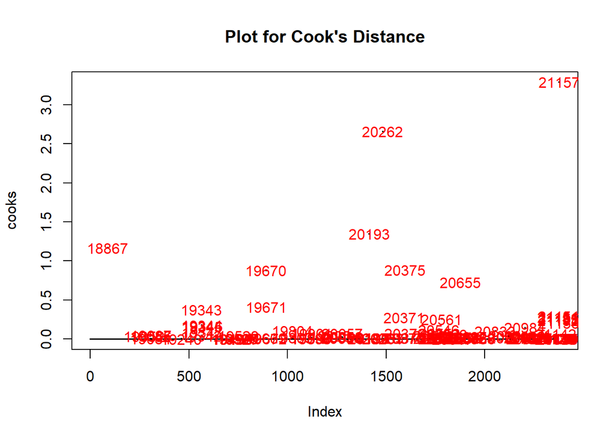

```r
cooks <- cooks.distance(m)
plot(cooks, pch=".", cex=1.5, main="Plot for Cook's Distance")
text(x=1:length(cooks),y=cooks, labels=ifelse(cooks>4/nrow(autoparts3), names(cooks), ""), col="red")
```

`이상치가 있는 데이터만 추출한다.`

```r
influential <- names(cooks)[(cooks > 4/nrow(autoparts3))]
autoparts3[rownames(autoparts3) %in% influential,]
```

```
##       fix_time a_speed b_speed separation s_separation rate_terms  mpa
## 18867     82.0   0.505   1.789      181.3        718.8         91 30.5
## 19052    109.9   0.491   1.525      172.4        726.0         91 29.7
## 19084     82.2   0.742   1.470      165.6        726.8         90 26.4
## 19085     82.1   0.498   1.552      184.5        722.9         91 29.8
## 19086     82.0   0.500   1.552      184.5        722.9         91 29.6
## 19087     82.0   0.498   1.552      184.5        722.9         90 29.8
## 19240     82.3   0.747   1.599      165.5        723.1         91 72.7
## 19342     82.1   0.748   1.536      171.8        725.6         91 26.3
## 19343     82.1   0.498   1.582      233.5        679.1         90 29.8
## 19344     81.8   0.502   1.582      233.5        679.1         90 30.0
## 19345     81.8   0.505   1.582      233.5        679.1         91 30.1
## 19346     81.9   0.503   1.582      233.5        679.1         91 30.0
## 19347     95.7   0.647   1.582      233.5        679.1         91 72.0
## 19496     81.9   0.651   1.480      220.5        677.6         91 73.5
```

[output cut: 213 more lines]

### 5.5 이상치 검출 5

#### 5.5.1평균에서 가장 먼 값

```r
#install.packages("outliers")
library(outliers)

outlier(autoparts3$c_thickness)
```

```
## [1] 56.6
```

```r
outlier(autoparts3$c_thickness, opposite=TRUE)
```

```
## [1] 5.9
```

#### 5.5.2 Local Outlier Factor

- 밀도를 기반으로 지역적 이상치를 식별
- 관측치의 밀도가 주변 밀도에 비해 훨씬 작다면(LOF점수가 크다면) 이상치로 판정
- 주변 관측치들이 밀집도에 따라 이상치 여부가 달라짐(지역성 locality 반영)
- 계절, 월, 주말…. 주변에 친구가 많은 데이터는 이상치로 판정하지 않음.

```r
#install.packages("DMwR")
library(DMwR)
```

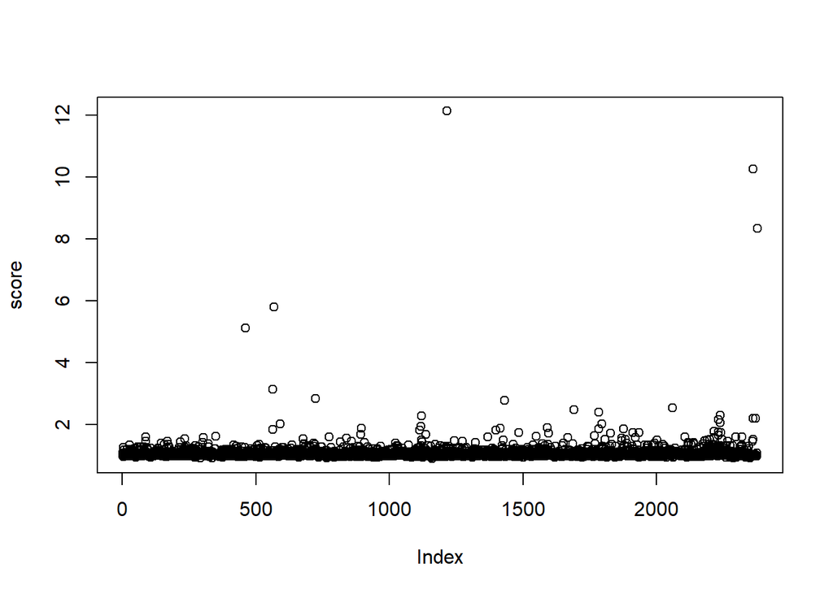

```r
score <-  lofactor(autoparts3, k=5)
plot(score)
```

```r
top5 <- order(score, decreasing = TRUE)[1:5]; top5
```

```
## [1] 1216 2363 2378  568  461
```

### example

#### 연습

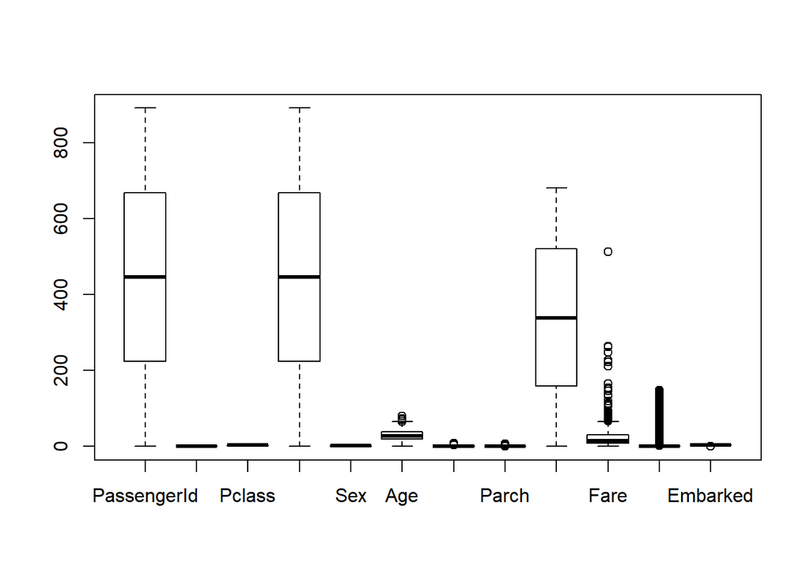

```r
# 타이타닉 데이터에 대한 boxplot 을 그리고, 이상치가 존재하는 변수를 탐색하시오.
titanic <- read.csv("train.csv", header=T)
boxplot(titanic)
```

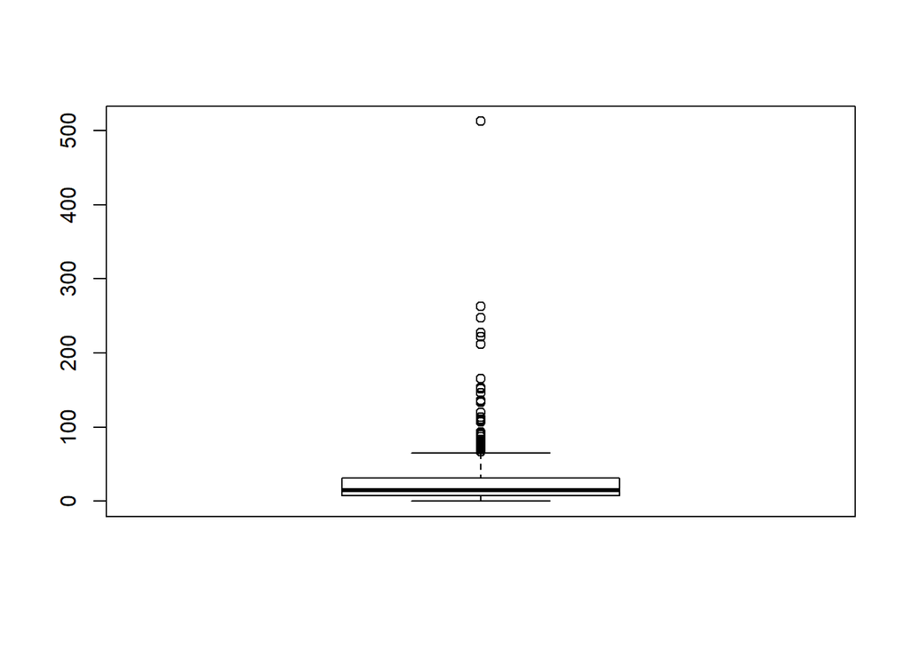

```r
#1. 이상치가 존재한다고 가장 의심할 수 있는 변수는 무엇인가 ?
 # 이산형 자료 중 Fare 변수가 가장 이상치가 존재할 것이라고  생각한다.

outlier <- boxplot(titanic$Fare)$out
```

```r
#2. 이상치 검출 1번에서 사용된 코드를 사용하여 이상치가 몇 개 발견되었는지를 파악하시오.
cat("다섯숫자요약을 통해 발견한 이상치 개수 : ", length(outlier),"개 \n")
```

```
## 다섯숫자요약을 통해 발견한 이상치 개수 :  116 개
```

```r
#3. 이상치를 제거한 데이터를 생성하시오.
lower <- which(titanic$Fare < fivenum(titanic$Fare)[2] - 1.5 * IQR(titanic$Fare))
upper <- which(titanic$Fare > fivenum(titanic$Fare)[4] + 1.5 * IQR(titanic$Fare))

titanic_rm_outlier <- titanic[c(upper,lower),]

#4. 이상치를 제거할 수 없게 되었다. 평균, 최빈값으로 대체하시오. (각 값을 계산하기 전 복사본을 만드시오.)
# 복사본 titanic_copy
titanic$outlier <- ifelse(titanic$Fare > fivenum(titanic$Fare)[4] + 1.5 * IQR(titanic$Fare),1,0)
titanic$Fare[titanic$outlier==1] <- as.numeric(names(sort(table(titanic$Fare), decreasing=T)[1]))


# head(sort(table(titanic$Fare)))
as.numeric(names(sort(table(titanic$Fare), decreasing=T)[1])) # Fare 변수의 최빈값 # 8.05.
```

```
## [1] 8.05
```

```r
mean(titanic$Fare) # Fare변수의 평균값 # 16.55
```

```
## [1] 16.54985
```